# Assignment3

Nickie Mitch

9/25/2020

```r
library(sf)
library(tidyverse)
library(ggthemes)
library(ggspatial)
library(units)
library(nngeo)
```

### Load Data

Sourced from the Open Indy Data Portal at https://data.indy.gov/

I considered cultural districts, parks, IndyGo bus stops, and Indiana Pacers Bikeshare docks. When necessary, I used neighborhoods boundaries as a base map for my plots.

```r
indy_neighborhoods <- st_read("https://opendata.arcgis.com/datasets/d5b4734bed3f49f9b2109ca9a0401886_10.kml", quiet=TRUE)

indy_cultural_districts <- st_read("https://opendata.arcgis.com/datasets/cee4c62348cd4dd0aadb3855bbf7692b_0.kml", quiet=TRUE)

indy_parks <- st_read("https://opendata.arcgis.com/datasets/106d14dad4864c4ea3a7bc80b7f73e3f_0.kml", quiet=TRUE)

indy_bus_stops <- st_read("https://opendata.arcgis.com/datasets/922ada43e0f046a1a2e0d252c0cb4945_4.kml", quiet=TRUE)

indy_bike_share <- st_read("https://opendata.arcgis.com/datasets/9c096fd62b8a4c7f8335556740c8ba23_2.kml", quiet=TRUE)
```

### Transform to Indiana East Plane (NAD83)

The Open Indy Data Portal specified this as the proper plane for these datasets.

```r
Indiana_Plane <- "+proj=tmerc +lat_0=37.5 +lon_0=-85.66666666666667 +k=0.9999666666666667 +x_0=100000 +y_0=250000 +ellps=GRS80 +units=m +no_defs"

indy_neighborhoods <- indy_neighborhoods %>% st_transform(Indiana_Plane)

indy_cultural_districts <- indy_cultural_districts %>% st_transform(Indiana_Plane)

indy_parks <- indy_parks %>% st_transform(Indiana_Plane)

indy_bus_stops <- indy_bus_stops %>% st_transform(Indiana_Plane)

indy_bike_share<- indy_bike_share %>% st_transform(Indiana_Plane)
```

### Rough Plot of All Variables

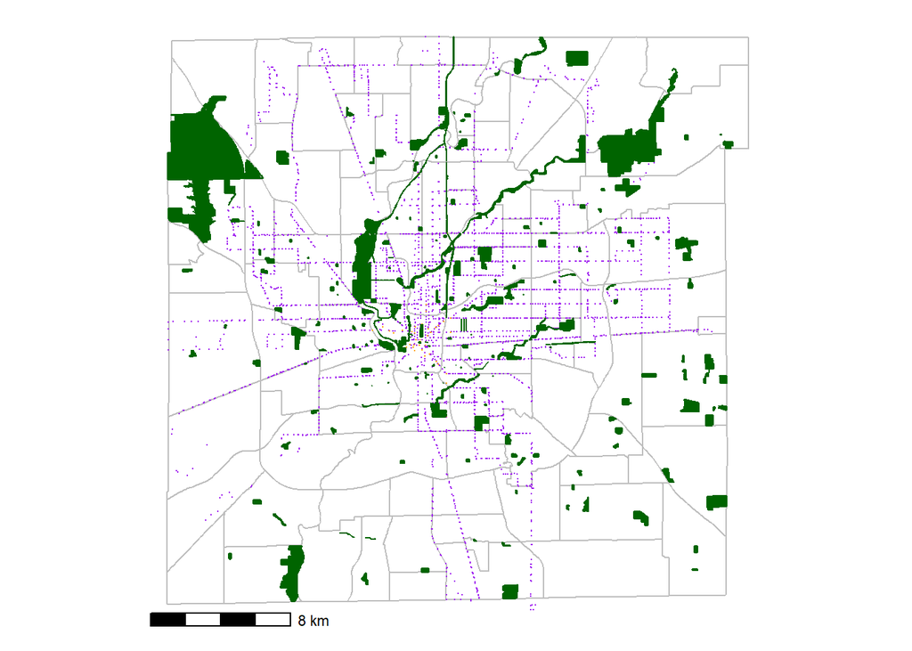

```r
ggplot(indy_neighborhoods) +
  geom_sf(fill = NA, color = "grey") +
    geom_sf(data = indy_bus_stops, color = "purple", size = 0.1) +
  geom_sf(data = indy_bike_share, color= "orange", size = 0.1) +
  geom_sf(data = indy_parks, fill = "darkgreen", color = "darkgreen") +
  theme_map() +
  annotation_scale()
```

### Calculation 1

The number and proportion of Indiana Pacers Bikeshare docks located within 80 meters (approximately one block) of an IndyGo Bus Stop.

```r
bus_buffer <- st_buffer(indy_bus_stops, dist = 80) %>%
  st_union()
```

```r
bike_bus <- indy_bike_share[bus_buffer,]
indy_bike_share <- indy_bike_share %>%
  st_join(bike_bus) %>%
  mutate(by_indy_bus_stops = !is.na(Name.y))
```

```r
n_bike_bus <- sum(indy_bike_share$by_indy_bus_stops)

n_bike_bus
```

```
## [1] 26
```

```r
n_bike <- length(indy_bike_share$by_indy_bus_stops)

pct_bike_bus <- n_bike_bus / n_bike

pct_bike_bus
```

```
## [1] 0.52
```

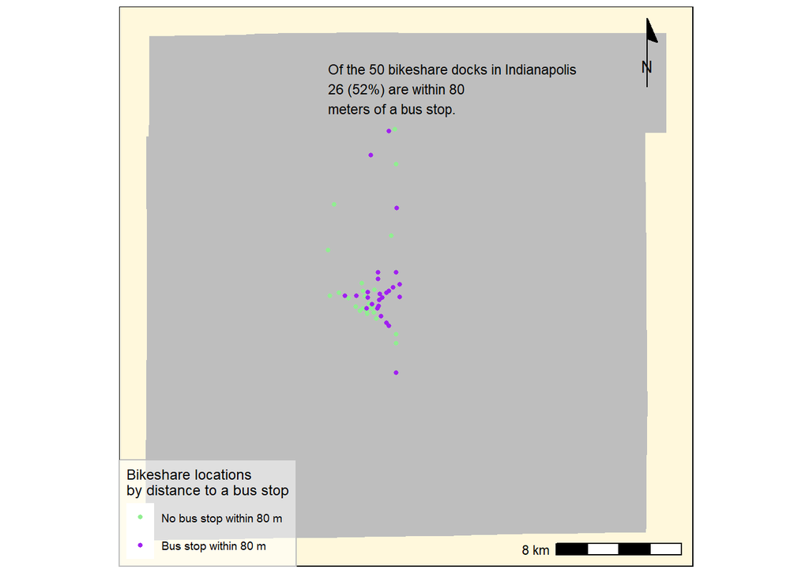

```r
left_side  <- st_bbox(indy_bike_share)$xmin
top_side <- st_bbox(indy_bike_share)$ymax

ggplot(indy_neighborhoods) +
  geom_sf(fill = "grey", color = NA) +
  geom_sf(data = indy_bike_share, size = 1,
          aes(color = by_indy_bus_stops)) +
  scale_color_manual(values = c("lightgreen", "purple"),
          name = "Bikeshare locations \nby distance to a bus stop",
          labels = c("No bus stop within 80 m",
                     "Bus stop within 80 m")) +
  annotation_scale(location = "br") +
  annotation_north_arrow(location = "tr",
                         style = north_arrow_minimal()) +
  annotate(geom = "text", x = left_side,
           y = top_side +1000,
           label = paste("Of the ",
                         prettyNum(n_bike, big.mark = ","),
                         " bikeshare docks in Indianapolis\n",
                         prettyNum(n_bike_bus, big.mark = ","),
                         " (",
                         prettyNum(100*pct_bike_bus, digits = 0),
                         "%) are within 80\nmeters of a bus stop.",
                         sep = ""),
           hjust = 0, vjust = 0, size = 3) +
  theme_map() +
  theme(panel.background = element_rect(fill = "cornsilk1"),
        legend.background = element_rect(fill = alpha("white", 0.5),
                                         color = "gray"))
```

### Calculation 2

The number and proportion of IndyGo Bus Stops located within 80 meters (approximately one block) of an Indiana Pacers Bikeshare dock.

```r
bike_buffer <- st_buffer(indy_bike_share, dist = 80) %>%
  st_union()
```

```r
bike_bus2 <- indy_bus_stops[bike_buffer,]
indy_bus_stops <- indy_bus_stops %>%
  st_join(bike_bus2) %>%
  mutate(by_indy_bike_share = !is.na(Name.y))
```

```r
n_bike_bus2 <- sum(indy_bus_stops$by_indy_bike_share)

n_bike_bus2
```

```
## [1] 49
```

```r
n_bus <- length(indy_bus_stops$by_indy_bike_share)

pct_bike_bus2 <- n_bike_bus2 / n_bus

pct_bike_bus2
```

```
## [1] 0.01430239
```

[figure not shown]

```r
left_side  <- st_bbox(indy_bus_stops)$xmin
right_side  <- st_bbox(indy_bus_stops)$xmax
bottom_side <- st_bbox(indy_bus_stops)$ymin
top_side <- st_bbox(indy_bus_stops)$ymax

ggplot(indy_neighborhoods) +
  geom_sf(fill = NA, color = NA) +
  geom_sf(data = indy_bus_stops, size = 1,
          aes(color = by_indy_bike_share)) +
  scale_color_manual(values = c("pink", "green"),
          name = "Bus stopsby distance \n to a bike share dock",
          labels = c("No bike share dock within 80 m",
                     "Bike share dock within 80 m")) +
  annotation_scale(location = "br") +
  annotation_north_arrow(location = "tr",
                         style = north_arrow_minimal()) +
  annotate(geom = "text", x = left_side,
           y = top_side - 3000,
           label = paste("Of the ",
                         prettyNum(n_bike, big.mark = ","),
                         " bus stops in Indianapolis\n",
                         prettyNum(n_bike_bus, big.mark = ","),
                         " (",
                         prettyNum(100*pct_bike_bus, digits = 0),
                         "%) are within 80\nmeters of a bike share dock.",
                         sep = ""),
           hjust = 0, vjust = 0, size = 3) +
  theme_map() +
  theme(panel.background = element_rect(fill = "cornsilk1"),
        legend.background = element_rect(fill = alpha("white", 0.5),
                                         color = "gray"))
```

### Calculation 3

The average distance between IndyGo Bus Stops and the nearest Indiana Pacers Bikeshare dock.

```r
indy_bus_stops <- indy_bus_stops %>%
  mutate(bike_dist = st_nn(indy_bus_stops, indy_bike_share,
                           returnDist = TRUE)$dist) %>%
  mutate(bike_dist = as.numeric(bike_dist))
```

```
## projected points
```

```r
avg_bike_bus_dist <- mean(indy_bus_stops$bike_dist)

avg_bike_bus_dist
```

[output not shown]

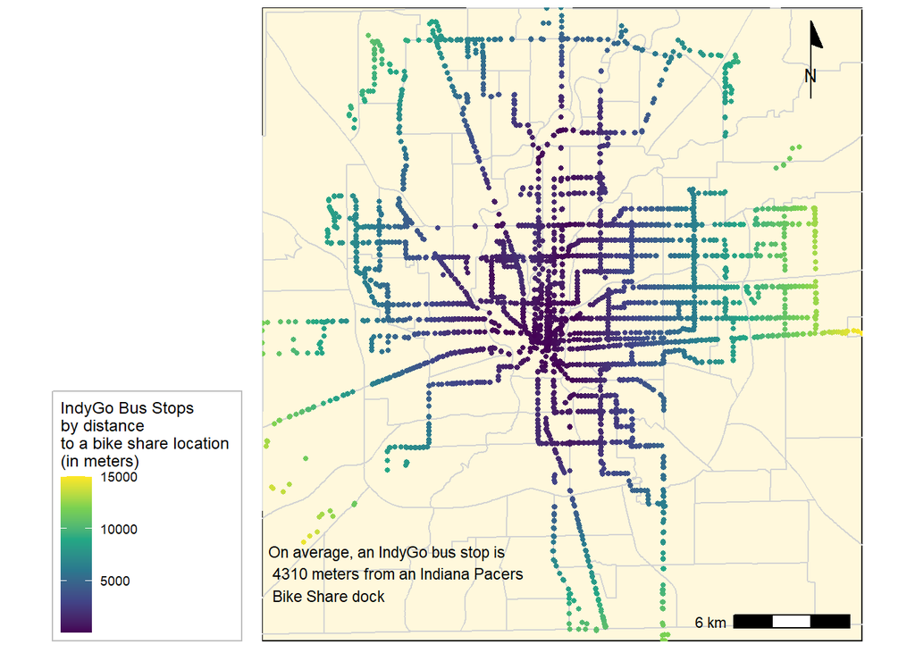

```r
right_side <- st_bbox(indy_bus_stops)$xmax
left_side  <- st_bbox(indy_bus_stops)$xmin
top_side <- st_bbox(indy_bus_stops)$ymax
bottom_side <- st_bbox(indy_bus_stops)$ymin


ggplot(indy_neighborhoods) +
  geom_sf(fill = NA, color = "lightgrey") +
  geom_sf(data = indy_bus_stops, size = 1,
          aes(color = bike_dist)) +
  coord_sf(xlim = c(left_side, right_side),
           ylim = c(bottom_side, top_side), expand = FALSE) +
  scale_color_viridis_c(name =
                          "IndyGo Bus Stops\nby distance \nto a bike share location \n(in meters)") +
  annotation_scale(location = "br") +
  annotation_north_arrow(location = "tr",
                         style = north_arrow_minimal()) +
  annotate(geom = "text", x = left_side + 300,
           y = bottom_side + 5000,
           label = paste("On average, an IndyGo bus stop is\n ",
                         prettyNum(avg_bike_bus_dist, digits = 3),
                         " meters from an Indiana Pacers\n Bike Share dock",
                         sep = ""),
           hjust = 0, vjust = 1, size = 3) +
  theme_map() +
  theme(panel.background = element_rect(fill = "cornsilk1"),
        legend.background = element_rect(fill = alpha("white", 0.5),
                                         color = "gray")) +
  theme(legend.position = "left")
```

### Calculation 4

The average distance between Indiana Pacers Bikeshare docks and the nearest IndyGo bus stop.

```r
indy_bike_share<- indy_bike_share %>%
  mutate(bus_dist = st_nn(indy_bike_share, indy_bus_stops,
                           returnDist = TRUE)$dist) %>%
  mutate(bus_dist = as.numeric(bus_dist))
```

```
## projected points
```

```r
avg_bike_bus_dist2 <- mean(indy_bike_share$bus_dist)

avg_bike_bus_dist2
```

```
## [1] 105.6769
```

[figure not shown]

```r
right_side <- st_bbox(indy_bus_stops)$xmax
left_side  <- st_bbox(indy_bus_stops)$xmin
top_side <- st_bbox(indy_bus_stops)$ymax
bottom_side <- st_bbox(indy_bus_stops)$ymin


ggplot(indy_neighborhoods) +
  geom_sf(fill = NA, color = "lightgrey") +
  geom_sf(data = indy_bike_share, size = 1,
          aes(color = bus_dist)) +
  coord_sf(xlim = c(left_side, right_side),
           ylim = c(bottom_side, top_side), expand = FALSE) +
  scale_color_viridis_c(name =
                          "Bike share docks\n by distance to \n nearest bus stop \n(in meters)") +
  annotation_scale(location = "br") +
  annotation_north_arrow(location = "tr",
                         style = north_arrow_minimal()) +
  annotate(geom = "text", x = left_side + 300,
           y = top_side - 550,
           label = paste("On average, an Indiana Pacers Bike Share dock is\n ",
                         prettyNum(avg_bike_bus_dist, digits = 3),
                         " meters from an IndyGo bus stop",
                         sep = ""),
           hjust = 0, vjust = 1, size = 3) +
  theme_map() +
  theme(panel.background = element_rect(fill = "cornsilk1"),
        legend.background = element_rect(fill = alpha("white", 0.5),
                                         color = "gray"))
```

### Calculation 5

The number and proportion of cultural districts that overlap with parks.

```r
indy_cultural_districts <- indy_cultural_districts %>%
  mutate(num_parks = lengths(st_overlaps(indy_cultural_districts, indy_parks))) %>%
  mutate(has_parks = num_parks > 0)

n_districts_parks <- sum(indy_cultural_districts$has_parks)

n_districts_parks
```

```
## [1] 2
```

```r
n_districts <- length(indy_cultural_districts$Name)

pct_districts_parks <- n_districts_parks / n_districts

pct_districts_parks
```

```
## [1] 0.4
```

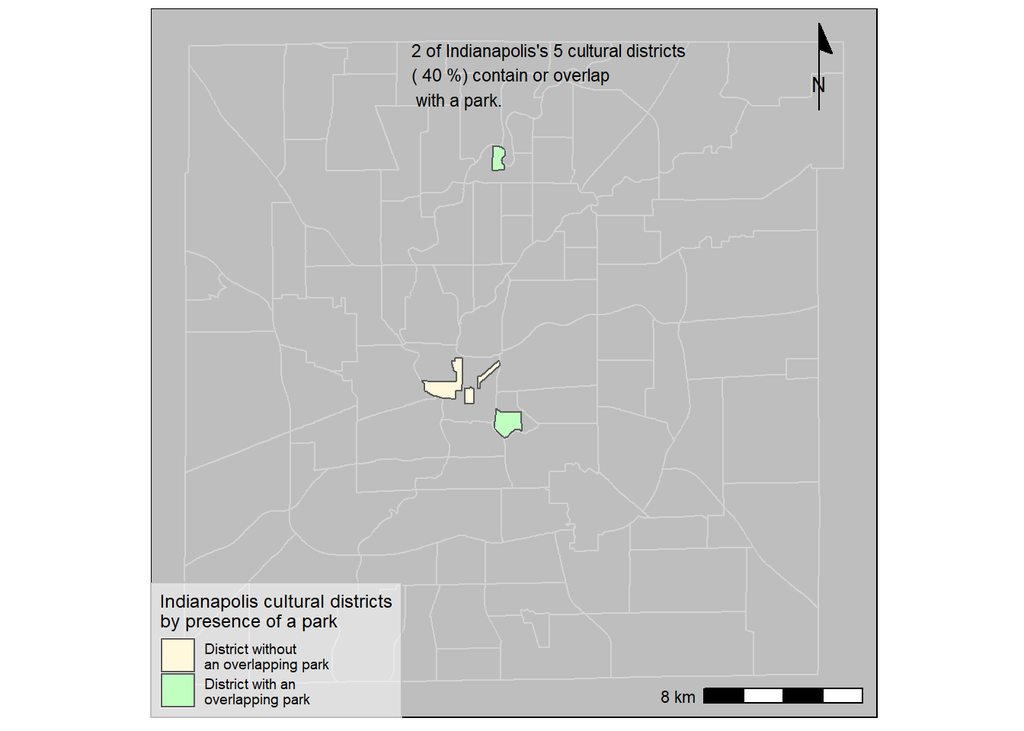

```r
left_side  <- st_bbox(indy_cultural_districts)$xmin
top_side <- st_bbox(indy_cultural_districts)$ymax

ggplot(indy_neighborhoods) +
  geom_sf(fill = NA, color = "lightgrey") +
  geom_sf(data = indy_cultural_districts,
          aes(fill = has_parks)) +
  scale_fill_manual(values = c("cornsilk1", "darkseagreen1"),
          name = "Indianapolis cultural districts\nby presence of a park",
          labels = c("District without\nan overlapping park",
                     "District with an\noverlapping park")) +
  annotation_scale(location = "br") +
  annotation_north_arrow(location = "tr",
                         style = north_arrow_minimal()) +
  annotate(geom = "text", x = left_side -500,
           y = top_side + 2000,
           label = paste(n_districts_parks ,
                         "of Indianapolis's",
                         length(indy_cultural_districts),
                         "cultural districts", "\n(",
                         prettyNum(100*pct_districts_parks, digits = 0),"%)", "contain or overlap \n with a park."),
           hjust = 0, vjust = 0, size = 3) +
  theme_map() +
  theme(panel.background = element_rect(fill = "gray"),
        legend.background = element_rect(fill = alpha("white", 0.5),
                                         color = "gray"))
```

### Calculation 6

The number and proportion of parks that contain or overlap overlap with cultural districts.

```r
indy_parks <- indy_parks %>%
  mutate(num_districts = lengths(st_overlaps(indy_parks, indy_cultural_districts))) %>%
  mutate(has_dist = num_districts > 0)

n_districts_parks2 <- sum(indy_parks$has_dist)

n_districts_parks2
```

```
## [1] 3
```

```r
n_parks <- length(indy_parks$Name)

pct_districts_parks2 <- n_districts_parks2 / n_parks

pct_districts_parks2
```

```
## [1] 0.008645533
```

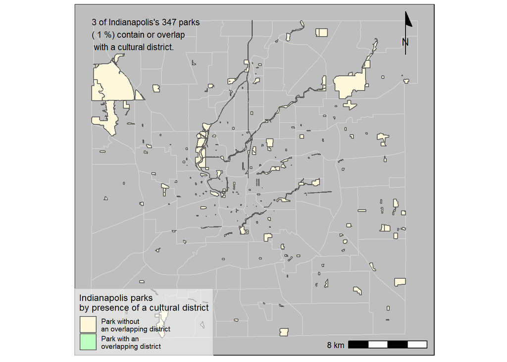

```r
left_side  <- st_bbox(indy_parks)$xmin
top_side <- st_bbox(indy_parks)$ymax

ggplot(indy_neighborhoods) +
  geom_sf(fill = NA, color = "lightgrey") +
  geom_sf(data = indy_parks,
          aes(fill = has_dist)) +
  scale_fill_manual(values = c("cornsilk1", "darkseagreen1"),
          name = "Indianapolis parks \nby presence of a cultural district",
          labels = c("Park without\nan overlapping district",
                     "Park with an\noverlapping district")) +
  annotation_scale(location = "br") +
  annotation_north_arrow(location = "tr",
                         style = north_arrow_minimal()) +
  annotate(geom = "text", x = left_side,
           y = top_side - 3000,
           label = paste(n_districts_parks2,
                         "of Indianapolis's",
                         length(indy_parks$Name),
                         "parks", "\n(",
                         prettyNum(100*pct_districts_parks2, digits = 0),"%)", "contain or overlap \n with a cultural district."),
           hjust = 0, vjust = 0, size = 3) +
  theme_map() +
  theme(panel.background = element_rect(fill = "gray"),
        legend.background = element_rect(fill = alpha("white", 0.5),
                                         color = "gray"))
```

### Calculation 7

The number and proportion of cultural districts that contain a bus stop.

```r
indy_cultural_districts <- indy_cultural_districts %>%
  mutate(num_bus = lengths(st_covers(indy_cultural_districts, indy_bus_stops))) %>%
  mutate(has_bus = num_bus > 0)

n_districts_bus <- sum(indy_cultural_districts$has_bus)

n_districts <- length(indy_cultural_districts$Name)

pct_districts_bus <- n_districts_bus / n_districts

n_districts_bus
```

```
## [1] 5
```

```r
pct_districts_bus
```

```
## [1] 1
```

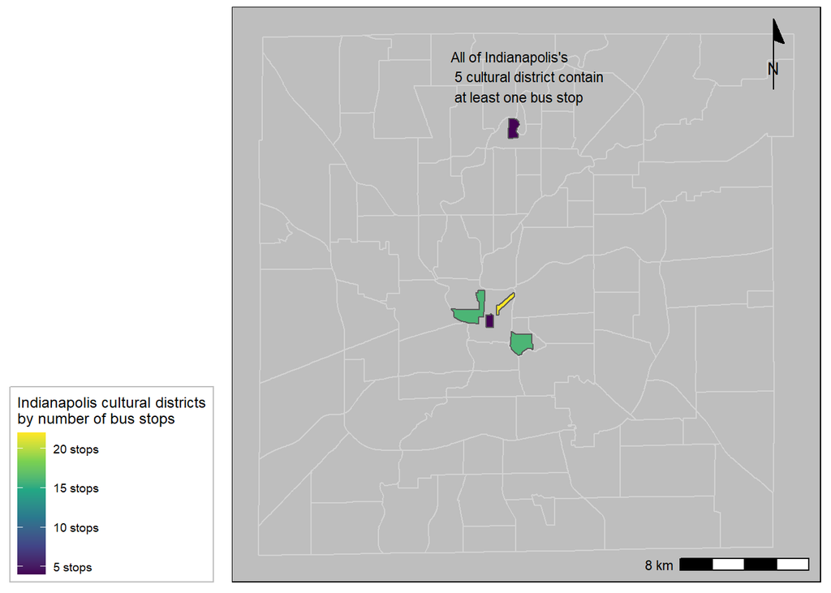

```r
left_side  <- st_bbox(indy_cultural_districts)$xmin
top_side <- st_bbox(indy_cultural_districts)$ymax

ggplot(indy_neighborhoods) +
  geom_sf(fill = NA, color = "lightgrey") +
  geom_sf(data = indy_cultural_districts,
          aes(fill = num_bus)) +
scale_fill_viridis_c(name = "Indianapolis cultural districts\nby number of bus stops",
                       breaks = breaks <- seq(0, 30, by = 5),
                       labels = paste(prettyNum(breaks, big.mark = ","),
                                      "stops")) +
  annotation_scale(location = "br") +
  annotation_north_arrow(location = "tr",
                         style = north_arrow_minimal()) +
  annotate(geom = "text", x = left_side,
           y = top_side + 1000,
           label = paste("All of Indianapolis's \n",
                         length(indy_cultural_districts$Name),
                         "cultural district contain \n",
                         "at least one bus stop"),
           hjust = 0, vjust = 0, size = 3) +
  theme_map() +
  theme(panel.background = element_rect(fill = "gray"),
        legend.background = element_rect(fill = alpha("white", 0.5),
                                         color = "gray")) +
  theme(legend.position = "left")
```

### Calculation 8

The number and proportion of parks that contain an IndyGo bus stop.

```r
indy_parks <- indy_parks %>%
  mutate(num_bus = lengths(st_covers(indy_parks, indy_bus_stops))) %>%
  mutate(has_bus = num_bus > 0)

n_park_bus <- sum(indy_parks$has_bus)

n_parks <- length(indy_parks$Name)

pct_park_bus <- n_park_bus / n_parks

n_park_bus
```

```
## [1] 20
```

```r
pct_park_bus
```

```
## [1] 0.05763689
```

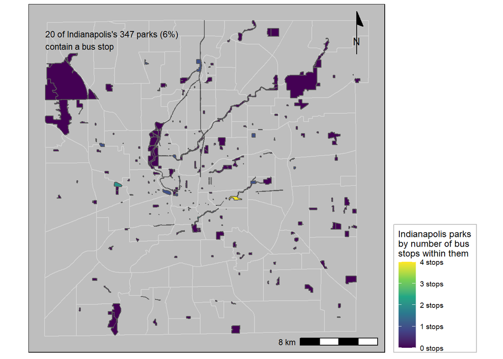

```r
left_side  <- st_bbox(indy_parks)$xmin
top_side <- st_bbox(indy_parks)$ymax

ggplot(indy_neighborhoods) +
  geom_sf(fill = NA, color = "lightgrey") +
  geom_sf(data = indy_parks,
          aes(fill = num_bus)) +
scale_fill_viridis_c(name = "Indianapolis parks\nby number of bus \nstops within them",
                       breaks = breaks <- seq(0, 10, by = 1),
                       labels = paste(prettyNum(breaks, big.mark = ","),
                                      "stops")) +
  annotation_scale(location = "br") +
  annotation_north_arrow(location = "tr",
                         style = north_arrow_minimal()) +
  annotate(geom = "text", x = left_side,
           y = top_side - 3000,
           label = paste(n_park_bus,
                         "of Indianapolis's",
                         length(indy_parks$Name),
                         "parks (6%) \ncontain",
                         "a bus stop"),
           hjust = 0, vjust = 0, size = 3) +
  theme_map() +
  theme(panel.background = element_rect(fill = "gray"),
        legend.background = element_rect(fill = alpha("white", 0.5),
                                         color = "gray")) +
  theme(legend.position = "right")
```